# Team_TAM_Case_Study01

10/6/2018

# MSDS 6306: Doing Data Science

## Case Study 01

### Question 1: How many breweries are present in each state?

```r
# load the library dplyr https://dplyr.tidyverse.org/
library(dplyr)
```

```r
# load ggplot2 library
library(ggplot2)
# load the data

fpbeer <- "/Users/andyh/Google Drive/Education/SMU/Courses/401 - Doing Data Science/Case Study 1/CaseStudy1/Beers.csv"
fpbrew <- "/Users/andyh/Google Drive/Education/SMU/Courses/401 - Doing Data Science/Case Study 1/CaseStudy1/Breweries.csv"

beer <- read.csv(fpbeer, header = TRUE, sep = ",")
breweries <- read.csv(fpbrew, header = TRUE, sep = ",")
# Rename "Name" column in brewaries to Brewery
breweries <- rename(breweries, Brewery = Name)
# Count breweries per state
BreweriesPerState <- count(breweries, State)
# Washington DC is not a state, so remove it.
BreweriesPerState <- BreweriesPerState[- grep("DC", BreweriesPerState$State), ]
# Change the column name "n" to "Breweries"
names(BreweriesPerState)[names(BreweriesPerState)=="n"] <- "Breweries"
# Sort the breweries in descending order
BreweriesPerState <- arrange(BreweriesPerState, desc(Breweries))
# Display the first 5
head(BreweriesPerState,5)
```

```
## # A tibble: 5 x 2
##   State Breweries
##   <fct>     <int>
## 1 " CO"        47
## 2 " CA"        39
## 3 " MI"        32
## 4 " OR"        29
## 5 " TX"        28
```

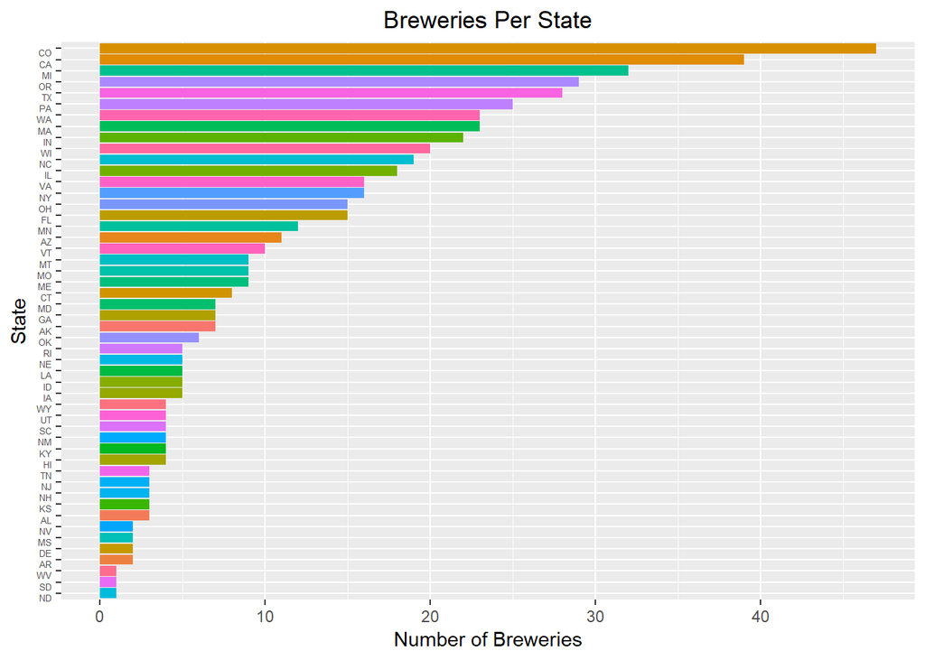

```r
# Plot the Breweris Per State
f <- ggplot(BreweriesPerState, aes(x=reorder(State, Breweries), y=(Breweries), fill=State)) + geom_bar(stat='identity') + coord_flip() + labs(title ="Breweries Per State", x = "State", y = "Number of Breweries") +theme(plot.title = element_text(hjust = 0.5)) + theme(legend.position = "none")

f <- f  + theme(axis.text.y = element_text(size = 5,
                                          hjust = 1,
                                          vjust = 1))
f
```

### Answer 1:

#### Here is our bar chart of breweries by state. It is to no one’s surprise that Colorado is leading the pack, closely trailed by California. Two states well known for producing vast varieties and quantities of beer.

### Question 2. Merge beer data with the breweries data. Print the first 6 observations and the last six observations to check the merged file.

```r
# merge the two df's
# Change the Brewary_ID in the beer df to Brew_ID so we can merge the two df's by Brew_ID
beer <- rename(beer, Brew_ID = Brewery_id)
merged_data <- inner_join(beer, breweries, by = "Brew_ID")
# Display the first 6 observations
head(merged_data,6)
```

```
##                  Name Beer_ID   ABV IBU Brew_ID
## 1            Pub Beer    1436 0.050  NA     409
## 2         Devil's Cup    2265 0.066  NA     178
## 3 Rise of the Phoenix    2264 0.071  NA     178
## 4            Sinister    2263 0.090  NA     178
## 5       Sex and Candy    2262 0.075  NA     178
## 6        Black Exodus    2261 0.077  NA     178
##                            Style Ounces                   Brewery City
## 1            American Pale Lager     12 10 Barrel Brewing Company Bend
## 2        American Pale Ale (APA)     12       18th Street Brewery Gary
## 3                   American IPA     12       18th Street Brewery Gary
## 4 American Double / Imperial IPA     12       18th Street Brewery Gary
## 5                   American IPA     12       18th Street Brewery Gary
## 6                  Oatmeal Stout     12       18th Street Brewery Gary
##   State
## 1    OR
## 2    IN
## 3    IN
## 4    IN
## 5    IN
## 6    IN
```

```r
# Display the last 6 observations
tail(merged_data,6)
```

```
##                             Name Beer_ID   ABV IBU Brew_ID
## 2405 Rocky Mountain Oyster Stout    1035 0.075  NA     425
## 2406                   Belgorado     928 0.067  45     425
## 2407               Rail Yard Ale     807 0.052  NA     425
## 2408             B3K Black Lager     620 0.055  NA     425
## 2409         Silverback Pale Ale     145 0.055  40     425
## 2410        Rail Yard Ale (2009)      84 0.052  NA     425
##                         Style Ounces                 Brewery   City State
## 2405           American Stout     12 Wynkoop Brewing Company Denver    CO
## 2406              Belgian IPA     12 Wynkoop Brewing Company Denver    CO
## 2407 American Amber / Red Ale     12 Wynkoop Brewing Company Denver    CO
## 2408              Schwarzbier     12 Wynkoop Brewing Company Denver    CO
## 2409  American Pale Ale (APA)     12 Wynkoop Brewing Company Denver    CO
## 2410 American Amber / Red Ale     12 Wynkoop Brewing Company Denver    CO
```